# **Song Popularity Analysis**

Darian Tocci and Marissa Vagnoni

Link to Our Website: https://dartocc.github.io/

# **Project Goals**

**Collaboration Plan:** Aside from breaks and traveling that will require zoom meetings, we will mainly be working on this project in person about 1-2 times a week using a shared google colab and pushing our changes to a shared GitHub respository. Additionally, we will communicate frequently over text with any brief ideas or concerns that need to be addressed in the moment. Lastly, we have created a progress timeline based on the rubric from our syllabus to ensure we are staying on track with each project milestone.

**Motivation**

As two individuals with a great love for music, we decided that this topic would be interesting, informative, and enjoyable to study.

**Research Questions**

- Is there a musical element recipe to creating a popular song?
- What are the typical trends in popular songs?
- Are there trends in streaming data that correlate with track popularity?

# **Data Tidying for "Song Popularity" Dataset**

This dataset is fairly tidy as is and there are no null values are present in any of the columns. There are a few alterations and data table combinations we could make to aid in analyzation.

```python
from google.colab import drive
drive.mount('/content/drive')
import pandas as pd
import matplotlib.pyplot as plt
import numpy as np
import io

file_path_song_data = '/content/drive/MyDrive/song_data.csv'
# Read the CSV
df_song_data = pd.read_csv(file_path_song_data)
```

```python
df_song_data.dtypes
```

|  | 0 |
| --- | --- |
| song_name | object |
| song_popularity | int64 |
| song_duration_ms | int64 |
| acousticness | float64 |
| danceability | float64 |
| energy | float64 |
| instrumentalness | float64 |
| key | int64 |
| liveness | float64 |
| loudness | float64 |
| audio_mode | int64 |
| speechiness | float64 |
| tempo | float64 |
| time_signature | int64 |
| audio_valence | float64 |

**dtype:** object

All columns are assigned the correct type besides audio_mode. This should be assigned as an object as it is categorical data.

Additionally, we will assign a string to each numerical label to clarify the meanings of these values. 1 represents a song in major and 0 represents a song in minor.

```python
df_song_data['audio_mode'] = df_song_data['audio_mode'].map({1: 'major', 0: 'minor'})
df_song_data['audio_mode'] = df_song_data['audio_mode'].astype(str)
```

**Table 1: Basic Musical Data**

This first table groups together basic musical elements that pertain to the structural attributes of each song.

```python
song_basic_data = df_song_data[['song_name', 'song_duration_ms', 'key', 'audio_mode', 'tempo', 'time_signature']].copy()
song_basic_data.head()
```

|  | song_name | song_duration_ms | key | audio_mode | tempo | time_signature |
| --- | --- | --- | --- | --- | --- | --- |
| 0 | Boulevard of Broken Dreams | 262333 | 8 | major | 167.060 | 4 |
| 1 | In The End | 216933 | 3 | minor | 105.256 | 4 |
| 2 | Seven Nation Army | 231733 | 0 | major | 123.881 | 4 |
| 3 | By The Way | 216933 | 0 | major | 122.444 | 4 |
| 4 | How You Remind Me | 223826 | 10 | major | 172.011 | 4 |

**Table 2: Popularity**

Tracks how well each song performs. A key aspect of song popularity is that it is not being used as a ranking. The popularity value given to each song is a score given to each song based on listener engagement from a streaming service.

```python
popularity_table = df_song_data[['song_name', 'song_popularity']].copy()
popularity_table.head()
```

|  | song_name | song_popularity |
| --- | --- | --- |
| 0 | Boulevard of Broken Dreams | 73 |
| 1 | In The End | 66 |
| 2 | Seven Nation Army | 76 |
| 3 | By The Way | 74 |
| 4 | How You Remind Me | 56 |

**Table 3: Audio Features**

Descriptive variables from an audio analysis.

```python
audio_features = df_song_data[['song_name', 'acousticness', 'danceability', 'energy',
                     'instrumentalness', 'liveness', 'loudness', 'speechiness', 'audio_valence']].copy()
audio_features.head()
```

|  | song_name | acousticness | danceability | energy | instrumentalness | liveness | loudness | speechiness | audio_valence |
| --- | --- | --- | --- | --- | --- | --- | --- | --- | --- |
| 0 | Boulevard of Broken Dreams | 0.005520 | 0.496 | 0.682 | 0.000029 | 0.0589 | -4.095 | 0.0294 | 0.474 |
| 1 | In The End | 0.010300 | 0.542 | 0.853 | 0.000000 | 0.1080 | -6.407 | 0.0498 | 0.370 |
| 2 | Seven Nation Army | 0.008170 | 0.737 | 0.463 | 0.447000 | 0.2550 | -7.828 | 0.0792 | 0.324 |
| 3 | By The Way | 0.026400 | 0.451 | 0.970 | 0.003550 | 0.1020 | -4.938 | 0.1070 | 0.198 |
| 4 | How You Remind Me | 0.000954 | 0.447 | 0.766 | 0.000000 | 0.1130 | -5.065 | 0.0313 | 0.574 |

# **Exploratory Data Analysis**

**Most Popular Vs. Least Popular**

```python
# Filtering songs with popularity 100 and 0
most_pop = df_song_data[df_song_data['song_popularity'] == 100]
least_pop = df_song_data[df_song_data['song_popularity'] == 0]

# Finding mean for each group
most_pop_avg = most_pop.mean(numeric_only=True)
least_pop_avg = least_pop.mean(numeric_only=True)

# Combining into one DataFrame for comparison
popularity_comparison = pd.DataFrame({
    'most_popular_avgs': most_pop_avg,
    'least_popular_avgs': least_pop_avg
})

print(popularity_comparison)
```

```
                  most_popular_avgs  least_popular_avgs
song_popularity            100.0000            0.000000
song_duration_ms        214289.0000       225549.658088
acousticness                 0.1910            0.205888
danceability                 0.6870            0.646309
energy                       0.7920            0.661555
instrumentalness             0.0000            0.128275
key                          5.0000            5.753676
liveness                     0.1670            0.188359
loudness                    -2.7490           -7.283570
speechiness                  0.0452            0.141242
tempo                      100.0150          125.781934
time_signature               4.0000            3.959559
audio_valence                0.6710            0.539374
```

This comparison can be used to find the major differences between popular and non-popular songs. This data can get us closer to our conclusion of which musical elements aid in a song's popularity. Some takeaways from the data above are that a louder track tends to be more popular and that a shorter song tends to be more popular. Elements such as key, time signature, and danceability appear to have very close averages and could potentially be considered void for the impact on a song's popularity. However, more data will need to be observed before this conclusion is met.

**Popularity Comparison Between Major and Minor Songs**

```python
summary = df_song_data.groupby('audio_mode').agg(
    count=('song_popularity', 'size'),
    avg_popularity=('song_popularity', 'mean')
)
print(summary)
```

```
            count  avg_popularity
audio_mode
major       11831       52.908123
minor        7004       53.133352
```

Songs in major typically have a happier, lighter feel that can be a factor in an upbeat mood or motivation. Songs in minor are typically sad and can aid in a calm, relaxed, or melancholy mood. This element can be important to see if happy or sad songs are typically more popular. From the data above we can see that there are a significantly higher amount of songs in major compared to minor, so this summarization may not be the most beneficial to use. However, when looking at the average popularity between the two, we can see that they are extremely similar. This may indicate that a song being in major or minor does not necessarily impact its popularity.

**Correlation Between Danceability and Popularity**

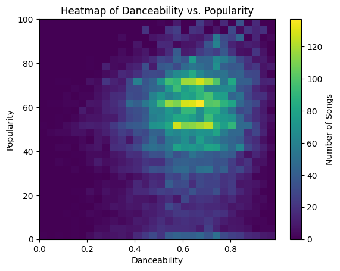

```python
plt.hist2d(df_song_data['danceability'], df_song_data['song_popularity'], bins=[30, 30], cmap='viridis')
plt.colorbar(label='Number of Songs')
plt.xlabel('Danceability')
plt.ylabel('Popularity')
plt.title('Heatmap of Danceability vs. Popularity')
```

The heat map above reflects that there are a high volume of songs that are more danceable (around 0.5-0.7) and they are scaled between 40-80 on the popularity scale. This may indicate that songs with a danceable attribute are moderately to highly popular amongst listeners.

**Popularity by Tempo Range**

```python
#create simple tempo bins
tempo_bins = [0, 80, 120, 160, 300]  # slow, medium, fast, very fast
tempo_labels = ['Slow', 'Medium', 'Fast', 'Very Fast']
df_song_data['tempo_range'] = pd.cut(df_song_data['tempo'], bins=tempo_bins, labels=tempo_labels, include_lowest=True)

#group by tempo range
summary_tempo = df_song_data.groupby('tempo_range', observed=False).agg(
    count=('song_popularity', 'size'),
    avg_popularity=('song_popularity', 'mean')
)
print(summary_tempo)
```

```
             count  avg_popularity
tempo_range
Slow          1087       51.786569
Medium        8266       53.771594
Fast          7427       52.537768
Very Fast     2055       52.134307
```

We divided up the songs into 4 different tempos: Slow, Medium, Fast, and Very Fast. The results show that medium-tempo songs are both the most common and have the highest average popularity. Slow and very fast songs are less frequent and slightly less popular on average. This show us that that songs with a more moderate tempo tend to be more popular.

# **Data Tidying for "Prediction of Music Genre" Dataset**

This dataset is quite similar to the previous, however, it includes older songs and a few extra musical elements that the previous set did not include. This could be useful in building our future model if we use some of this data and combine it with data of the previous set.

This is a fairly tidy dataset, however there are some issues surrounding data types and ways to organize the tables into different datasets based on groupings.

```python
file_path_music_genre = '/content/drive/MyDrive/music_genre.csv'
# Read the CSV
df_music_genre_not_clean = pd.read_csv(file_path_music_genre)
```

```python
from google.colab import drive
drive.mount('/content/drive')
```

There are some null values present in a few of the columns so we are going to drop the rows containing those null values. These values appear to be missing completely at random so dropping them will not result in any bias. Additionally, the dataset is so large that the amount of rows being dropped will not cause a significant loss of data.

```python
#drop a row if it has a NaN value present in any column
df_music_genre = df_music_genre_not_clean.dropna().copy()
```

Right now, pandas is assuming tempo is an object when it should really be a float. We can fix this by correcting the data type assignment of tempo.

```python
df_music_genre["tempo"] = pd.to_numeric(df_music_genre["tempo"], errors = "coerce")
```

```python
df_music_genre.dtypes
```

|  | 0 |
| --- | --- |
| instance_id | float64 |
| artist_name | object |
| track_name | object |
| popularity | float64 |
| acousticness | float64 |
| danceability | float64 |
| duration_ms | float64 |
| energy | float64 |
| instrumentalness | float64 |
| key | object |
| liveness | float64 |
| loudness | float64 |
| mode | object |
| speechiness | float64 |
| tempo | float64 |
| obtained_date | object |
| valence | float64 |
| music_genre | object |

**dtype:** object

Next, obtained_date is not a relevant variable to the overall goal of the project so that column can be dropped.

```python
df_music_genre.drop("obtained_date", axis = 1, inplace = True)
```

Next, we want to change the column headings to match our previously used dataset. This can be valuable for merging the datasets if they have songs in common.

```python
df_music_genre.rename(columns = {"track_name": "song_name", "popularity": "song_popularity", "duration_ms": "song_duration_ms", "mode": "audio_mode", "valence": "audio_valence"}, inplace = True)
```

```python
df_music_genre.head()
```

|  | instance_id | artist_name | song_name | song_popularity | acousticness | danceability | song_duration_ms | energy | instrumentalness | key | liveness | loudness | audio_mode | speechiness | tempo | audio_valence | music_genre |
| --- | --- | --- | --- | --- | --- | --- | --- | --- | --- | --- | --- | --- | --- | --- | --- | --- | --- |
| 0 | 32894.0 | Röyksopp | Röyksopp's Night Out | 27.0 | 0.00468 | 0.652 | -1.0 | 0.941 | 0.79200 | A# | 0.115 | -5.201 | Minor | 0.0748 | 100.889 | 0.759 | Electronic |
| 1 | 46652.0 | Thievery Corporation | The Shining Path | 31.0 | 0.01270 | 0.622 | 218293.0 | 0.890 | 0.95000 | D | 0.124 | -7.043 | Minor | 0.0300 | 115.002 | 0.531 | Electronic |
| 2 | 30097.0 | Dillon Francis | Hurricane | 28.0 | 0.00306 | 0.620 | 215613.0 | 0.755 | 0.01180 | G# | 0.534 | -4.617 | Major | 0.0345 | 127.994 | 0.333 | Electronic |
| 3 | 62177.0 | Dubloadz | Nitro | 34.0 | 0.02540 | 0.774 | 166875.0 | 0.700 | 0.00253 | C# | 0.157 | -4.498 | Major | 0.2390 | 128.014 | 0.270 | Electronic |
| 4 | 24907.0 | What So Not | Divide & Conquer | 32.0 | 0.00465 | 0.638 | 222369.0 | 0.587 | 0.90900 | F# | 0.157 | -6.266 | Major | 0.0413 | 145.036 | 0.323 | Electronic |

Next, we are going to group the variables into smaller datatables based on different groupings.

**Table 1: Track Identifiers**

This table contains information based on identifying atributes to each song.

```python
song_identifying_data = df_music_genre[['instance_id', 'artist_name', 'song_name', 'music_genre']].copy()
song_identifying_data.head()
```

|  | instance_id | artist_name | song_name | music_genre |
| --- | --- | --- | --- | --- |
| 0 | 32894.0 | Röyksopp | Röyksopp's Night Out | Electronic |
| 1 | 46652.0 | Thievery Corporation | The Shining Path | Electronic |
| 2 | 30097.0 | Dillon Francis | Hurricane | Electronic |
| 3 | 62177.0 | Dubloadz | Nitro | Electronic |
| 4 | 24907.0 | What So Not | Divide & Conquer | Electronic |

**Table 2: Popularity**

This datatable just contains the populairty metrics for each song.

```python
song_popularity_data = df_music_genre[['song_name', 'song_popularity']].copy()
song_popularity_data.head()
```

|  | song_name | song_popularity |
| --- | --- | --- |
| 0 | Röyksopp's Night Out | 27.0 |
| 1 | The Shining Path | 31.0 |
| 2 | Hurricane | 28.0 |
| 3 | Nitro | 34.0 |
| 4 | Divide & Conquer | 32.0 |

**Table 3: Musical Structure**

This datatable contains information surrounding the musical structure of each song. This can be used to see if a particular musical style effects populairty.

```python
song_musical_structure = df_music_genre[['song_duration_ms', 'tempo', 'key', 'audio_mode']].copy()
song_musical_structure.head()
```

|  | song_duration_ms | tempo | key | audio_mode |
| --- | --- | --- | --- | --- |
| 0 | -1.0 | 100.889 | A# | Minor |
| 1 | 218293.0 | 115.002 | D | Minor |
| 2 | 215613.0 | 127.994 | G# | Major |
| 3 | 166875.0 | 128.014 | C# | Major |
| 4 | 222369.0 | 145.036 | F# | Major |

**Table 4: Audio Features**

This table just contains attributes surrounding the audio features for each song. This can be used to see if a particular audio type effects song popularity.

```python
song_audio_features = df_music_genre[['acousticness', 'danceability', 'energy', 'instrumentalness', 'liveness', 'loudness', 'speechiness', 'audio_valence']].copy()
song_audio_features.head()
```

|  | acousticness | danceability | energy | instrumentalness | liveness | loudness | speechiness | audio_valence |
| --- | --- | --- | --- | --- | --- | --- | --- | --- |
| 0 | 0.00468 | 0.652 | 0.941 | 0.79200 | 0.115 | -5.201 | 0.0748 | 0.759 |
| 1 | 0.01270 | 0.622 | 0.890 | 0.95000 | 0.124 | -7.043 | 0.0300 | 0.531 |
| 2 | 0.00306 | 0.620 | 0.755 | 0.01180 | 0.534 | -4.617 | 0.0345 | 0.333 |
| 3 | 0.02540 | 0.774 | 0.700 | 0.00253 | 0.157 | -4.498 | 0.2390 | 0.270 |
| 4 | 0.00465 | 0.638 | 0.587 | 0.90900 | 0.157 | -6.266 | 0.0413 | 0.323 |

# **Exploratory Data Analysis**

Similar to the previous dataset, we will see how the averages for each variable differ between the most popular songs and the least popular.

```python
#filter songs with popularity 100 and 0
most_pop = df_music_genre[df_music_genre['song_popularity'] == 99]
least_pop = df_music_genre[df_music_genre['song_popularity'] == 0]

#find mean for each group
most_pop_avg = most_pop.mean(numeric_only=True)
least_pop_avg = least_pop.mean(numeric_only=True)

#combine into one dataFrame for comparison
popularity_comparison = pd.DataFrame({
    'most_popular_avgs': most_pop_avg,
    'least_popular_avgs': least_pop_avg
})
print(popularity_comparison)
```

```
                  most_popular_avgs  least_popular_avgs
instance_id            84744.000000        55074.367435
song_popularity           99.000000            0.000000
acousticness               0.163000            0.821325
danceability               0.833000            0.366734
song_duration_ms      149520.000000       234898.799712
energy                     0.539000            0.211362
instrumentalness           0.000002            0.409631
liveness                   0.101000            0.255047
loudness                  -7.399000          -20.280941
speechiness                0.178000            0.065332
tempo                     99.947000          107.049799
audio_valence              0.385000            0.276059
```

This offers greater distances between the most popular and least popular compared to the previous dataset. Here we can see that acousticness, danceability, song length, instrumentallness, and loudness offer noitceable differences indicating a pattern between the difference in the most popular and least popular songs.

**Genre Vs. Popularity**

Here we are going to look at the correlation between a song's genre and its popularity.

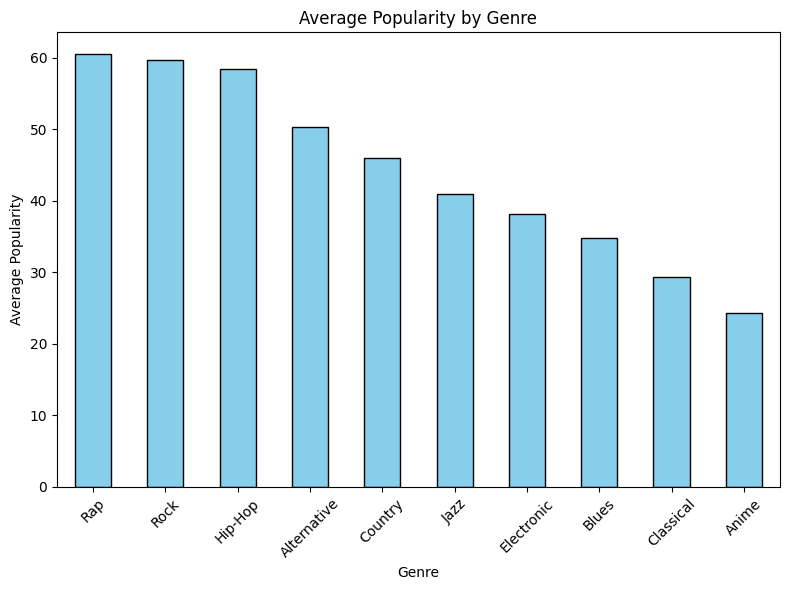

```python
#grouping by genre and getting the average popularity for each
genre_popularity = df_music_genre.groupby('music_genre')['song_popularity'].mean().sort_values(ascending=False)

#plotting
plt.figure(figsize=(8,6))
genre_popularity.plot(kind='bar', color='skyblue', edgecolor='black')


plt.xlabel('Genre')
plt.ylabel('Average Popularity')
plt.title('Average Popularity by Genre')
plt.xticks(rotation=45)
plt.tight_layout()

plt.show()
```

We can see that rap is the most popular genre of music and anime is the least popular. Along with rap, rock and Hip-Hop are also quite popular.

Now that we have this information, we want to see how different musical elements correspond to these genres. This could hint as to what musical elements are causing such popularity.

**Average Musical Element Values for Each Music Genre**

```python
#grouping by genre to see the mean of each numeric attribute
genre_comparison = df_music_genre.groupby('music_genre').mean(numeric_only=True)
filtered = genre_comparison.loc[['Rap', 'Rock', 'Hip-Hop']]
filtered
```

| music_genre | instance_id | song_popularity | acousticness | danceability | song_duration_ms | energy | instrumentalness | liveness | loudness | speechiness | tempo | audio_valence |
| --- | --- | --- | --- | --- | --- | --- | --- | --- | --- | --- | --- | --- |
| Rap | 55408.4536 | 60.4974 | 0.169057 | 0.696605 | 196508.7920 | 0.651301 | 0.009084 | 0.198035 | -6.668337 | 0.186707 | 120.585501 | 0.454999 |
| Rock | 56025.3756 | 59.6412 | 0.191394 | 0.539230 | 212818.3128 | 0.687792 | 0.054656 | 0.185961 | -7.224354 | 0.053403 | 122.669614 | 0.520361 |
| Hip-Hop | 56253.0368 | 58.3996 | 0.179093 | 0.717373 | 198395.9458 | 0.644334 | 0.010836 | 0.200870 | -6.851158 | 0.207044 | 120.154134 | 0.474927 |

Here we can see that popular genres are moreso on the danceable side, offer an energy around 0.6-0.7, and are on the less acoustic side. This information is valuable in seeing what attributes create a popular song, in correspondence to its genre. This is useful to see since our other dataset does not contain a genre category.

**Genre Based Mean Audio Features**

Next, we will narrow down the musical elements and just take a look at the audio features: energy, danceability, and acousticness, to see if there are any relevent or useful correlations. These specific attributes were selected due to having similar ranges.

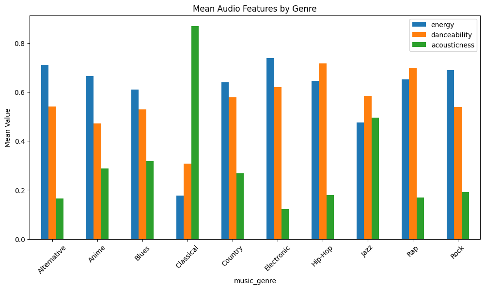

```python
#genre based mean audio features

features = ['energy','danceability','acousticness']

genre_means = df_music_genre.groupby("music_genre")[features].mean()

plt.figure(figsize=(12,6))
genre_means.plot(kind='bar', figsize=(12,6))
plt.title("Mean Audio Features by Genre")
plt.xticks(rotation=45)
plt.ylabel("Mean Value")
plt.show()
```

This data is valuable to loook at when addressing potential predictors for a genre. There are vast differences between particular genres and their audible elements such as Classical having a high acousticness or Electronic having a high level energy.

**Correlation Heatmap for Numeric Musical Elements**

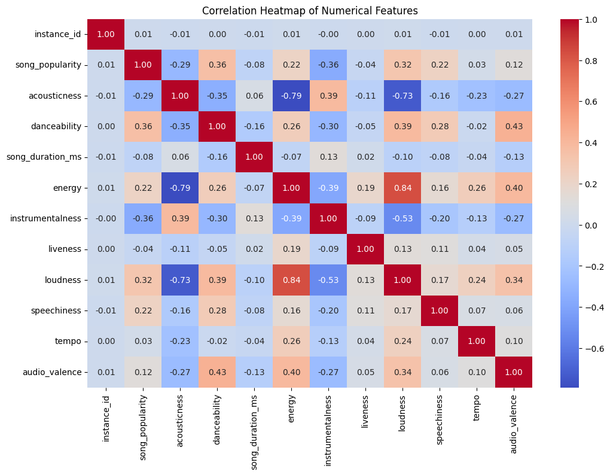

```python
#correlation heatmap for all numeric features
import matplotlib.pyplot as plt
import seaborn as sns


numeric_df = df_music_genre.select_dtypes(include=['float64', 'int64'])

plt.figure(figsize=(12, 8))
sns.heatmap(numeric_df.corr(),
            annot=True,
            fmt= '.2f',
            cmap='coolwarm')
plt.title("Correlation Heatmap of Numerical Features")
plt.show()
```

We can see above that popular songs are not strongly correlated to tempo, liveness, audio valence, and song duration. This can aid in recognizing which musical elements are not favoried in popular songs. We can see that loudness and energy are strongly correlated within songs and that energy and loudness are also strongly correlated. We can make the assumption that these types of songs are not favorable with this heatmap.

**Density Plot for Feature Comparisons By Genre**

Next, we are going to look at some density plots to observe how different song elements appear in different genres. This can potentially aid in our genre prediction model.

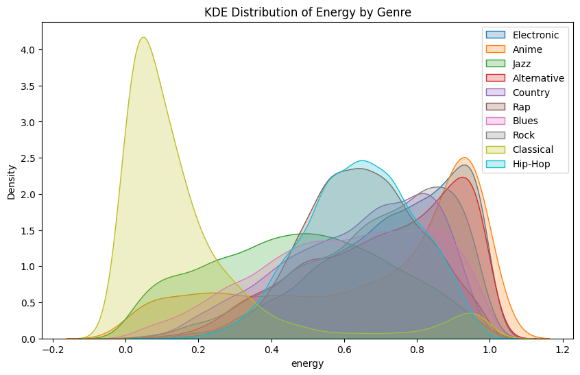

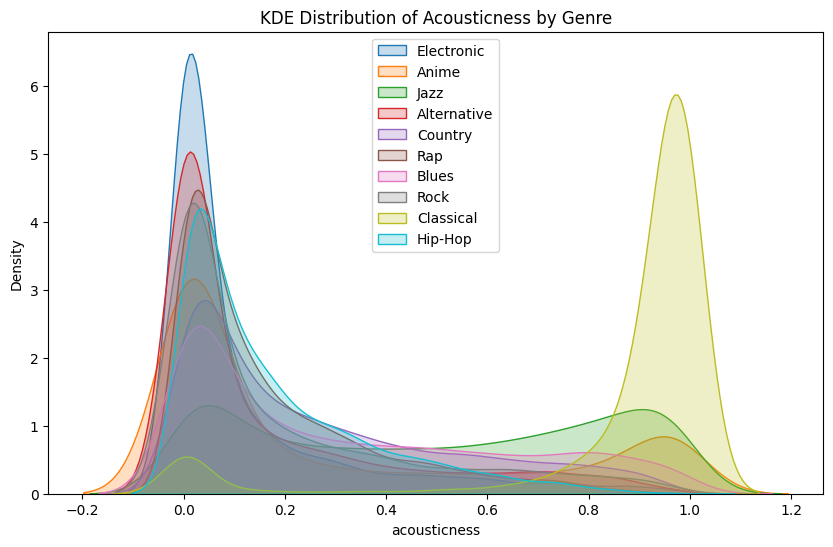

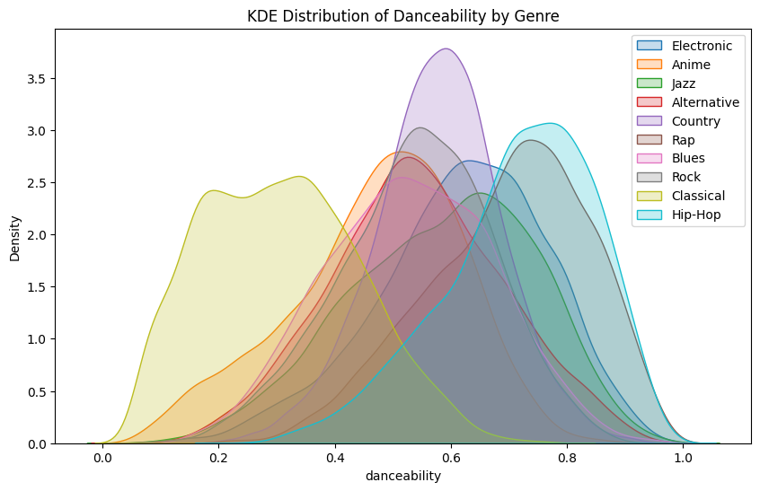

```python
#density plot for feature comparison



for feature in ['energy','acousticness','danceability']:
    plt.figure(figsize=(10,6))
    for genre in df_music_genre['music_genre'].unique():
        sns.kdeplot(
            df_music_genre[df_music_genre['music_genre']==genre][feature],
            label=genre,
            fill=True,
            alpha=0.25
        )
    plt.title(f"KDE Distribution of {feature.capitalize()} by Genre")
    plt.xlabel(feature)
    plt.legend()
    plt.show()
```

This EDA is helpful for us, because density plots show differences in feature shapes, not just averages. So, it helps us to visualize the seperation in genres, for example we can notice that energy for classical music is on the lower side and that Rap and Hip-Hop are almost exactly the same. Additionally, we can see that Classical and Electronic are essentially oppposites in acousticness. Lastly, we can see the large differences between Alternative and Classical genres in terms of danceability.

# **Data Tidying for "Most Streamed Spotify Songs 2024" Dataset**

Since we are basing the "popularity" metric off of Spotify streams, we decided to incorporate this dataset of the most streamed spotify songs in 2024 to see how other factors such as TikTok and YouTube performance, Playlist Counts, and similar factors may effect a song's popularity.

```python
file_path_streaming_data = '/content/drive/MyDrive/Most_Streamed_Spotify_Songs_2024.csv'
#file_path_streaming_data ='/content/drive/MyDrive/Most Streamed Spotify Songs 2024.csv'

df_streaming_data_not_clean = pd.read_csv(file_path_streaming_data, encoding='latin1') #encoding latin1 due to byte error
```

First, we are going to drop the columns that are not going to be useful for this specific analysis. These columns include album name, artist, release date, ISRC, and all time rank since we have track score and spotify streams to determine how popular each song is. Lastly, we will drop TIDAL popularity since all of the values in the column are null. Additionally, we are going to drop Soundcloud streams and SiriusXM spins since they contain a lot of null values and will cause a lot of the data to be dropped.

```python
#drop unneccesary columns and create new dataframe
columns_to_drop = ['Album Name', 'Artist', 'Release Date', 'ISRC', 'All Time Rank', 'TIDAL Popularity', 'Soundcloud Streams', 'SiriusXM Spins']
df_streaming_data_new = df_streaming_data_not_clean.drop(columns=columns_to_drop)
```

Next we are going to drop the rows containing null values. This will cause our dataset to drastically decrease, however, the data is missing at random so dropping these rows will not cause bias.

```python
df_streaming_data = df_streaming_data_new.dropna().copy()
```

To prove this, below I will show the frequency of certain track scores with the untidy dataset compared to the frequency with the tidy dataset. This is to show that the spread of tracks with a certain score (popularity) are not being significantly removed from the dataset.

```python
#Unskewing Data by applying log transformation
df_streaming_data_not_clean['Track Score_Log'] = np.log1p(df_streaming_data_not_clean['Track Score'])
df_streaming_data['Track Score_Log2'] = np.log1p(df_streaming_data['Track Score'])
```

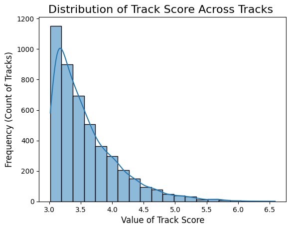

```python
#plot histogram to show frequency of track scores
sns.histplot(data= df_streaming_data_not_clean, x='Track Score_Log', kde=True, bins=20)

plt.title(f'Distribution of Track Score Across Tracks ', fontsize=16)
plt.xlabel(f'Value of Track Score', fontsize=12)
plt.ylabel('Frequency (Count of Tracks)', fontsize=12)
plt.show()
```

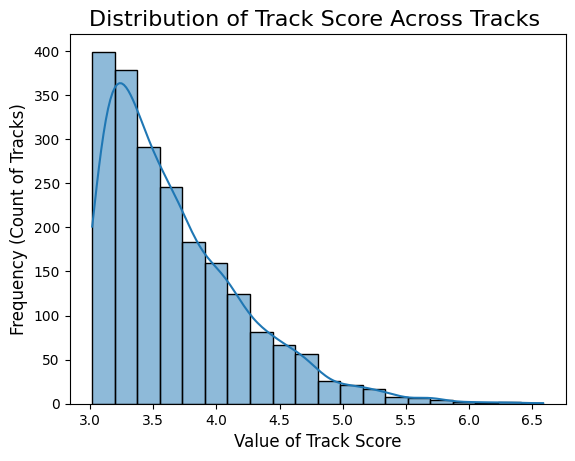

```python
#plot histogram to show frequency of track scores
sns.histplot(data= df_streaming_data, x='Track Score_Log2', kde=True, bins=20)

plt.title(f'Distribution of Track Score Across Tracks ', fontsize=16)
plt.xlabel(f'Value of Track Score', fontsize=12)
plt.ylabel('Frequency (Count of Tracks)', fontsize=12)
plt.show()
```

```python
#drop log column created since we do not need it anymore
df_streaming_data = df_streaming_data.drop(columns='Track Score_Log2').copy()
```

Next, we noticed that a lot of the columns with integer values contain commas seperating the larger numbers. This is causing them to be assigned as objects instead of integers. First, we will remove the commas from the numbers and then assign them to the correct data type (integer).

```python
#create list of columns with commas
integer_columns = ['Spotify Streams',
                   'Spotify Playlist Count',
                   'Spotify Playlist Reach',
                   'YouTube Views',
                   'YouTube Likes',
                   'TikTok Posts',
                   'TikTok Likes',
                   'TikTok Views',
                   'YouTube Playlist Reach',
                   'AirPlay Spins',
                   'Deezer Playlist Reach',
                   'Pandora Streams',
                   'Pandora Track Stations',
                   'Shazam Counts']
#loop through the columns and remove the commas
for col in integer_columns:
    #use .str.replace to remove all commas from the string values
    df_streaming_data[col] = df_streaming_data[col].str.replace(',', '')

#check the data type and reassign incorrect "object" types
for col in integer_columns:
    df_streaming_data[col] = pd.to_numeric(df_streaming_data[col], errors='coerce')
```

We have to take care of the rest of the columns that did not have commas and assigned them as integers.

```python
#create list of columns without commas and assigned as objects
integer_columns = [ 'Spotify Popularity',
                    'Apple Music Playlist Count',
                    'Deezer Playlist Count',
                    'Amazon Playlist Count']

#convert remaining columns to integers instead of floats
df_streaming_data[integer_columns] = df_streaming_data[integer_columns].astype('Int64')
```

Success! We have assigned the correct data types to each column and we can move on to data analysis.

```python
df_streaming_data.dtypes
```

|  | 0 |
| --- | --- |
| Track | object |
| Track Score | float64 |
| Spotify Streams | int64 |
| Spotify Playlist Count | int64 |
| Spotify Playlist Reach | int64 |
| Spotify Popularity | Int64 |
| YouTube Views | int64 |
| YouTube Likes | int64 |
| TikTok Posts | int64 |
| TikTok Likes | int64 |
| TikTok Views | int64 |
| YouTube Playlist Reach | int64 |
| Apple Music Playlist Count | Int64 |
| AirPlay Spins | int64 |
| Deezer Playlist Count | Int64 |
| Deezer Playlist Reach | int64 |
| Amazon Playlist Count | Int64 |
| Pandora Streams | int64 |
| Pandora Track Stations | int64 |
| Shazam Counts | int64 |
| Explicit Track | int64 |

**dtype:** object

# **Exploratory Data Analysis**

**Dataset Heatmap**

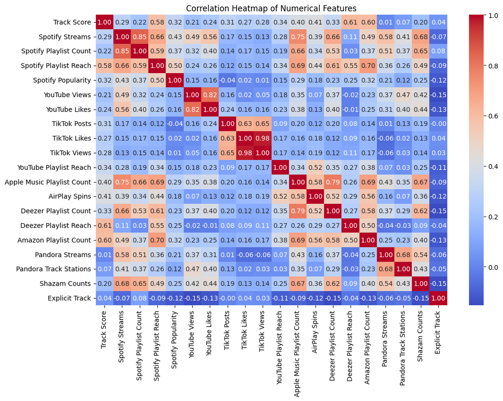

```python
import numpy as np

numeric_df = df_streaming_data.select_dtypes(include=['float64', 'int64'])

plt.figure(figsize=(12, 8))
sns.heatmap(numeric_df.corr(),
            annot=True,
            fmt= '.2f',
            cmap='coolwarm')
plt.title("Correlation Heatmap of Numerical Features")
plt.show()
```

**YouTube Views vs. Track Score**

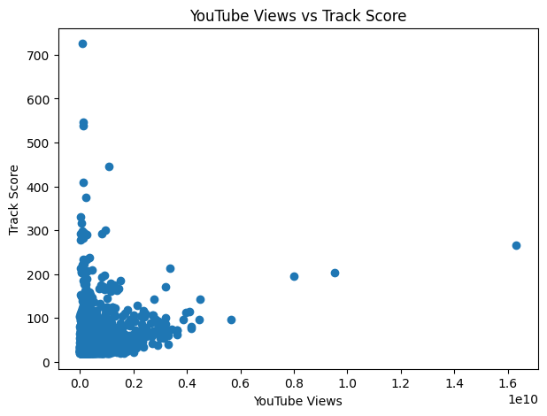

```python
plt.figure(figsize=(7,5))
plt.scatter(df_streaming_data["YouTube Views"], df_streaming_data["Track Score"])
plt.xlabel("YouTube Views")
plt.ylabel("Track Score")
plt.title("YouTube Views vs Track Score")
plt.show()
```

Here we can see that even some of the tracks with the highest score do not have that many YouTube Views, so we can rule out this platform as a place that leads the way for popular songs. Below we will analyze YouTube likes to confirm this theory.

**YouTube Likes vs Track Score**

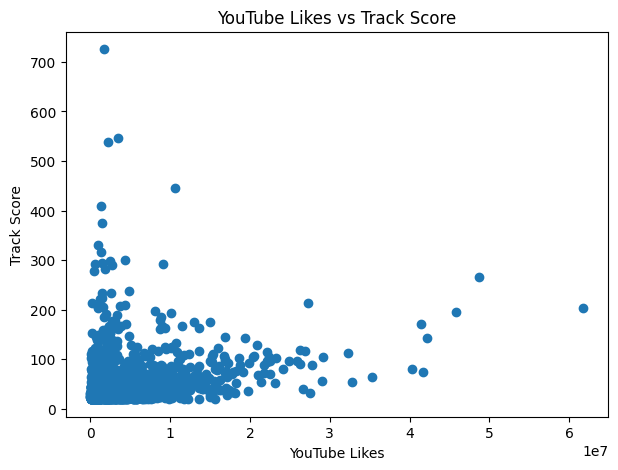

```python
plt.figure(figsize=(7,5))
plt.scatter(df_streaming_data["YouTube Likes"], df_streaming_data["Track Score"])
plt.xlabel("YouTube Likes")
plt.ylabel("Track Score")
plt.title("YouTube Likes vs Track Score")
plt.show()
```

Similar to views, there is no apparent correlation between YouTube likes and the rating of a track. This confirms that YouTube is not a platform that can be reliable to determine music popularity.

# **Hypothesis**

From our EDA of these three datasets we can recognize a few commonn trends. In our danceability analysis from our "Song Popularity" dataset, we can see that danceable songs tend to be ranked above a 50 in popularity scores. Additionally, when we did our most popular vs. least popular comparison we can see clear differences between loudness and tempo where songs that are "louder" tend to be more popular and songs with a moderate tempo similar to pop and contemporary tend to be more popular. Next, in our "Music Genre" dataset analysis we can see that Rap, Rock, and Hip-Hop are the genres with the highest popularity score. These three genres share similar numbers in elements such as energy, liveness, loudness, tempo, and audio valence. In correspondance to these numbers, we are forming the hypothesis that songs with a lively and upbeat vibe tend to be more popular. This does not necessarily mean extremely upbeat, such as house music or EDM music, but songs that are walkable and may have an impact on your mood and motions in a positive way.

# **Linear Regression Models**

**Song Popularity Linear Regression Model**

First, we are going to analyze a linear regression model on our "Song Popularity" dataset to see the relationship between song popularity and musical elements, and how this could be used for predictions.

```python
from sklearn.model_selection import train_test_split
from sklearn.linear_model import LinearRegression
from sklearn.metrics import r2_score, mean_squared_error, mean_absolute_error

#define independent variable musical elements and y dependent variable song popularity
X_cols = ['danceability',
          'acousticness',
          'instrumentalness',
          'key',
          'speechiness',
          'energy',
          'liveness',
          'loudness',
          'tempo',
          'time_signature',
          'audio_valence']
X = df_song_data[X_cols]
Y = df_song_data['song_popularity']

#split the data into 80% for training and 20% for testing
X_train, X_test, Y_train, Y_test = train_test_split(X, Y, test_size=0.2, random_state=42)


#linear regression model training
model = LinearRegression()
model.fit(X_train, Y_train)

#predictions for test set
Y_pred = model.predict(X_test)

#evaluation metrics
r2 = r2_score(Y_test, Y_pred)
mse = mean_squared_error(Y_test, Y_pred)
rmse = np.sqrt(mse)
mae = mean_absolute_error(Y_test, Y_pred) # Added MAE as discussed

#feature influences
coefficients = pd.DataFrame(model.coef_, X_cols, columns=['Coefficient'])

#results
print("Linear Regression Model Summary")
print(f"Independent Variables: {X_cols}")
print(f"Dependent Variable: Target_Popularity")

print("\nPerformance Metrics")
print(f"R-squared (R^2) Score: {r2:.4f}")
print(f"Root Mean Squared Error (RMSE): {rmse:.2f}")
print(f"Mean Absolute Error (MAE): {mae:.2f}")

print("\nMusical Feature Influence")
print(coefficients)
```

```
Linear Regression Model Summary
Independent Variables: ['danceability', 'acousticness', 'instrumentalness', 'key', 'speechiness', 'energy', 'liveness', 'loudness', 'tempo', 'time_signature', 'audio_valence']
Dependent Variable: Target_Popularity

Performance Metrics
R-squared (R^2) Score: 0.0421
Root Mean Squared Error (RMSE): 21.49
Mean Absolute Error (MAE): 17.05

Musical Feature Influence
                  Coefficient
danceability        13.432053
acousticness        -3.522401
instrumentalness   -10.284559
key                 -0.088282
speechiness         -2.481499
energy             -11.943769
liveness            -4.740494
loudness             0.743494
tempo               -0.008376
time_signature       1.306423
audio_valence       -8.700607
```

From the results above, we can conclude that this model is not sufficient for music popularity prediction. The R² value indicates that the means popularity is not drastically effected by these musical elements with a 4.2% variation in song popularity. The RMSE and MAE indicate a high prediction error of about 21.49 or 17.05 in popularity score. Danceability appears to have a strong positive effect on music popularity which coincides with our EDA analysis of the first dataset. Audio Valence has a strong negative effect on music popularity which actually indicates that songs that sound more "sad" may be more popular which does not match our hypothesis. This indicates that we may need to do some rethinking on our initial impressions of the data.

**Music Genre Dataset Linear Regression Model**

Next, we are going to analyze a linear regression model on our "Music Genre" dataset to see the relationship between song popularity and musical elements, and how this could be used for predictions. We hope to see better results from this model compared to the previous model.

```python
from sklearn.model_selection import train_test_split
from sklearn.linear_model import LinearRegression
from sklearn.metrics import r2_score, mean_squared_error, mean_absolute_error

#define independent variable musical elements and y dependent variable song popularity
X_cols = ['acousticness',
          'danceability',
          'song_duration_ms',
          'energy',
          'instrumentalness',
          'liveness',
          'loudness',
          'speechiness',
          'audio_valence']
X = df_music_genre[X_cols]
Y = df_music_genre['song_popularity']

#split the data into 80% for training and 20% for testing
X_train, X_test, Y_train, Y_test = train_test_split(X, Y, test_size=0.2, random_state=42)


#linear regression model training
model = LinearRegression()
model.fit(X_train, Y_train)

#predictions for test set
Y_pred = model.predict(X_test)

#evaluation metrics
r2 = r2_score(Y_test, Y_pred)
mse = mean_squared_error(Y_test, Y_pred)
rmse = np.sqrt(mse)
mae = mean_absolute_error(Y_test, Y_pred) # Added MAE as discussed

#feature influences
coefficients = pd.DataFrame(model.coef_, X_cols, columns=['Coefficient'])

#results
print("Multiple Linear Regression Model Summary")
print(f"Independent Variables: {X_cols}")
print(f"Dependent Variable: Target_Popularity")

print("\nPerformance Metrics")
print(f"R-squared (R^2) Score: {r2:.4f}")
print(f"Root Mean Squared Error (RMSE): {rmse:.2f}")
print(f"Mean Absolute Error (MAE): {mae:.2f}")

print("\nMusical Feature Influence")
print(coefficients)
```

```
Multiple Linear Regression Model Summary
Independent Variables: ['acousticness', 'danceability', 'song_duration_ms', 'energy', 'instrumentalness', 'liveness', 'loudness', 'speechiness', 'audio_valence']
Dependent Variable: Target_Popularity

Performance Metrics
R-squared (R^2) Score: 0.2318
Root Mean Squared Error (RMSE): 13.72
Mean Absolute Error (MAE): 10.80

Musical Feature Influence
                   Coefficient
acousticness     -6.318135e+00
danceability      1.880638e+01
song_duration_ms -6.443006e-07
energy           -7.334247e+00
instrumentalness -1.095017e+01
liveness         -6.239370e+00
loudness          3.306788e-01
speechiness       1.568677e+01
audio_valence    -4.167593e+00
```

This model performs better than the previous one, but is not the most reliable source to use. The R² value indicates that the means popularity is only slightly effected by these musical elements with a 23.18% variation in song popularity. The RMSE and MAE indicate a moderate prediction error of about 13.72 or 10.80 in popularity score. This is also a better performance than our previous model. Danceability still appears to have a strong positive effect on music popularity, similar to our previous model which helps our hypothesis. Loudness can be a small indicator for popularity, showing a small positive effect on popularity. Additionally, speechiness has a strong positive efect on popularity indicating that songs with more lyrical content tend to be more popular which supports our hypothesis. Audio valence still has a negative effect showing that "sadder" songs may have a tendency to be popular.

# **K-Nearest Neighbors Classifier Model**

**Predicting Genre with K-NN Classification Model**

Since our linear regression models did not have a great outcome, but we know that genre can be a good indicator of song popularity, we decided to make a K-NN classification model that predicts a song's genre based off of an array of musical elements. This is built from the music genre dataset; however, this could be beneficial for our "Song Popularity" dataset in predicting a song's popularity. If a song falls under a certain genre we can assess it's musical elements to see how they may effect the song's popularity.

```python
from sklearn.preprocessing import StandardScaler
from sklearn.neighbors import KNeighborsClassifier
import pandas as pd

#numeric and categorical features
numeric_features = ["acousticness",
                    "danceability",
                    "energy",
                    "instrumentalness",
                    "liveness",
                    "loudness",
                    "speechiness",
                    "audio_valence"]

categorical_features = ["key"]

#one-hot encode the key column
X_cat = pd.get_dummies(df_music_genre[categorical_features])

#extract numeric features
X_num = df_music_genre[numeric_features]

#scale numeric features
scaler = StandardScaler()
X_num_scaled = scaler.fit_transform(X_num)

#combine scaled numeric values one-hot categorical variable
X_train = np.concatenate([X_num_scaled, X_cat.values], axis=1)

y_train = df_music_genre["music_genre"]

#fit the kNN classifier
model = KNeighborsClassifier(n_neighbors=15)
model.fit(X_train, y_train)

#create test example
x_new = pd.DataFrame({
    "acousticness": [0.169057],
    "danceability": [0.696605],
    "energy": [0.651301],
    "instrumentalness": [0.009084],
    "liveness": [0.198035],
    "loudness": [-6.668337],
    "speechiness": [0.186707],
    "audio_valence": [0.454999],
    "key": ["A#"]
})

#one-hot encode the new key using the SAME columns
x_new_cat = pd.get_dummies(x_new[["key"]])

#make sure same columns exist (fill missing with 0)
x_new_cat = x_new_cat.reindex(columns=X_cat.columns, fill_value=0)

#scale numeric part
x_new_num_scaled = scaler.transform(x_new[numeric_features])

#combine
x_new_sc = np.concatenate([x_new_num_scaled, x_new_cat.values], axis=1)

#predictions
prediction_label = model.predict(x_new_sc)
prediction_probability = model.predict_proba(x_new_sc)

print(prediction_label)
print(prediction_probability)
```

```
['Hip-Hop']
[[0.06666667 0.         0.         0.         0.13333333 0.
  0.4        0.         0.4        0.        ]]
```

# **Conclusion**

```python
%%shell
jupyter nbconvert --to html "/content/drive/MyDrive/Data_Science_Project.ipynb"
```

[output not shown]